# Prática_04 - Prática de Baseado em Especificação e Teste Estrutural

PPGCC12 - Teste de Software

Author

Reginaldo Ré

Published

September 5, 2026

## O problema implementado a ser testado

### Descrição geral

Considere a descrição mostrada a seguir de um pequeno método que faz o preenchimento à esquerda de uma string usando outra string.

### Especificação de requisitos

- O método `preenche()`:
  - Preenche à esquerda uma string com uma string especificada. Preenche com um tamanho de `size`;
  - `public static String preenche(final String str, final int size, String stringPreenche)`
- `str`: a string a ser preenchida;
  - pode ser `null`;
- `size`: o tamanho máximo da string preenchida;
- `stringPreenche`: a string usada para preencher;
  - `null` ou vazio é tratado como se fosse um espaço em branco;
- O método retorna:
  - uma string preenchida à esquerda,
  - a string original se o preenchimento não for necessário,
  - ou `null` se uma string com o valor `null` for dada como entrada.
- Por exemplo, se for dada a string `abc` como entrada, e o caracter “-” como string de preenchimento, e 5 como o tamanho máximo, o programa deve retornar `--abc`.

## O trabalho prático

### Instruções de entrega

A solução deve ser enviada em um arquivo em formato `.zip` com o nome `RA.zip`, no qual “<RA>” é o número de seu RA. Por exemplo, um aluno com RA 123456 deve enviar um arquivo com o nome `123456.zip`.

### Implemente uma solução para a especificação de requisitos

Implemente uma solução em Java usando como base o projeto da prática anterior `identifier`. Sua implementação deve obedecer à seguinte assinatura de método:

> `public static String preenche(final String str, final int size, String stringPreenche)`.

### Teste a solução implementada usando teste baseado em especificação

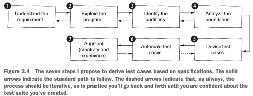

Figure 1: Processo usado no Teste baseado em Especificação.

### Teste a solução implementada usando teste estrutural

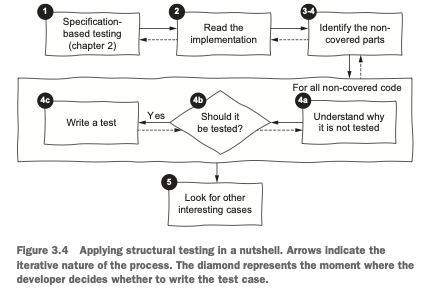

Figure 2: Processo usado no Teste Estrutural.

Após usar o **teste baseado em especificação** use o **teste estrutural** (Figure 2) e melhore seus testes e seu relatório, de maneira que seu relatório tenha:

1. Uma seção do relatório contendo uma descrição dos casos de teste criados a partir da utilização do critério MC/DC:
   - Não use os outros critérios, apenas o MC/DC;
   - Deve conter a tabela verdade e uma explicação de como os testes foram derivados;
2. Uma seção do relatório deve conter as informações de cobertura de código produzido pelo Jacoco antes e após adicionados os testes criados usando MC/DC;
3. Uma seção do relatório deve descrever eventuais erros e defeitos encontrados no código.

## Dicas

Use as dicas do projeto anterior, `identifier`.